# Practical machine learning

## Backgrownd

The data for this assignment can be found in http://groupware.les.inf.puc-rio.br/har. (see the section on the Weight Lifting Exercise Dataset), and explicitly from Velloso, E.; Bulling, A.; Gellersen, H.; Ugulino, W.; Fuks, H. Qualitative Activity Recognition of Weight Lifting Exercises. Proceedings of 4th International Conference in Cooperation with SIGCHI (Augmented Human ’13) . Stuttgart, Germany: ACM SIGCHI, 2013.

It is necessary to determine how well barbell are performed by subjects equiped with accelerometers on the belt, arm, forearm, and dumbells. For this purpose, I build a predictive model in which the exercise of barbell lifting is performed correctly or not.

## Packages

First of all, specific packages should be loaded in order to use them.

```r
library(caret)
library(randomForest)
library(Hmisc)
```

```r
library(corrplot)
```

## Data

Then, data should be readed to overview potential problems. In this case, the training and testing datasets present missing values named as NA or directly as blank.

```r
train <- read.csv("http://d396qusza40orc.cloudfront.net/predmachlearn/pml-training.csv", header = TRUE, na.strings = c("NA", ""))
test <- read.csv("http://d396qusza40orc.cloudfront.net/predmachlearn/pml-testing.csv", header = TRUE, na.strings = c("NA", ""))
```

After typing dim(train), I saw that the train dataset is made from 19622 observations of 160 variables. As mentioned, removing NAs is a must to avoid problems.

```r
Train<- train[,colSums(is.na(train))==0]
Test<- test[,colSums(is.na(test))==0]
dim(Train)
```

```
## [1] 19622    60
```

```r
head(Train)
```

```
##   X user_name raw_timestamp_part_1 raw_timestamp_part_2   cvtd_timestamp
## 1 1  carlitos           1323084231               788290 05/12/2011 11:23
## 2 2  carlitos           1323084231               808298 05/12/2011 11:23
## 3 3  carlitos           1323084231               820366 05/12/2011 11:23
## 4 4  carlitos           1323084232               120339 05/12/2011 11:23
## 5 5  carlitos           1323084232               196328 05/12/2011 11:23
## 6 6  carlitos           1323084232               304277 05/12/2011 11:23
##   new_window num_window roll_belt pitch_belt yaw_belt total_accel_belt
## 1         no         11      1.41       8.07    -94.4                3
## 2         no         11      1.41       8.07    -94.4                3
## 3         no         11      1.42       8.07    -94.4                3
## 4         no         12      1.48       8.05    -94.4                3
## 5         no         12      1.48       8.07    -94.4                3
## 6         no         12      1.45       8.06    -94.4                3
##   gyros_belt_x gyros_belt_y gyros_belt_z accel_belt_x accel_belt_y
```

[output cut: 76 more lines]

Now, more than half of the original columns have been removed to facilitate calculations. But I still made more data manipulations since some variables did not represent data from accelerometer measures or participant’s data. These variables include: X, user_name, raw_timestamp_part_1, raw_timestamp_part_2, cvtd_timestamp, new_window and num_window.

```r
deleteColumns <- grepl("X|user_name|new_window|num_window|raw_timestamp_part_1|raw_timestamp_part_2|cvtd_timestamp", colnames(Train))
OKtrain <- Train[, !deleteColumns]
OKtest <- Test[, !deleteColumns]
```

Finally, I had 53 columns in both datasets.

## Spliting the data

After done these modifications, I split the OKtraining set into a training set with the 70% of the observations, and a validation set with the 30% of the observations. This way, I was able to develop cross validation in this model.

```r
splitTrain = createDataPartition(y = OKtrain$classe, p = 0.7, list = FALSE)
trainTrain = OKtrain[splitTrain, ]
trainValidation = OKtrain[-splitTrain, ]
```

## Correlations between variables

Looking at the correlations between the variables in the datasets, it is possible to remove highly correlated predictors from this analysis and replace them with weighted combinations of predictors. As the target of the project is to predict the way participants did the exercises, I saw that this information is stored in the variable classe in the training data set. In addition, I plotted the correlation between pairs of predictors.

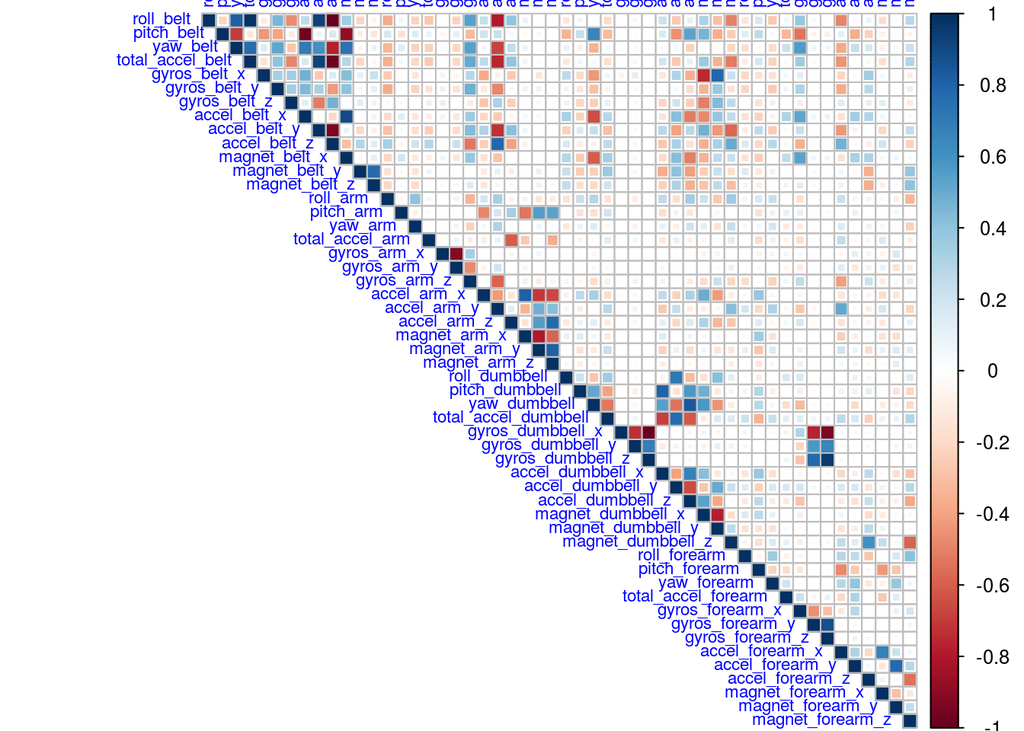

```r
correlMatrix <- cor(trainTrain[, -53])
corrplot(correlMatrix, order = "original", method = "square", type = "upper", tl.cex= 0.7, tl.col = rgb(0, 0, 1))
```

In a few words, the darker blue and red squares represent high positive and high negative correlations, respectively. Addionally, some pairs of variables are highly correlated. I achieved this with the following instructions:

```r
which(correlMatrix > 0.98 & correlMatrix != 1)
```

```
## [1]   4 157
```

```r
correlMatrix[which(correlMatrix > 0.98 & correlMatrix != 1)]
```

```
## [1] 0.981 0.981
```

```r
correlMatrix[which(correlMatrix < -0.98 )]
```

```
## [1] -0.9921 -0.9921 -0.9848 -0.9848
```

## Predictive model: Approach 1

For this project, I carried out two approaches. But first it is necessary to pre-process the data with a principal component analysis. I focused on the key column “classe” which I wanted to predict. Next, using the predict function on the pre-processed training and validation data, allowed preparing the data to the optimal conditions.

```r
preProcTrain <- preProcess(trainTrain[, -53], method = "pca", thresh = 0.99)
trainPredict <- predict(preProcTrain, trainTrain[, -53])
validationTestPC <- predict(preProcTrain, trainValidation[, -53])
```

I used as first approach the randomForest model function on the whole dataset prior splitting it (OKtrain dataset). After trying several number of trees and taking into account the dimensions of the data OKtrain, I determined that a good ntree parameter is 1050.

```r
approach1 <- randomForest(classe ~ ., data = OKtrain, ntree = 1050)
approach1
```

```
##
## Call:
##  randomForest(formula = classe ~ ., data = OKtrain, ntree = 1050)
##                Type of random forest: classification
##                      Number of trees: 1050
## No. of variables tried at each split: 7
##
##         OOB estimate of  error rate: 0.25%
## Confusion matrix:
##      A    B    C    D    E class.error
## A 5579    1    0    0    0   0.0001792
## B    9 3785    3    0    0   0.0031604
## C    0    7 3414    1    0   0.0023378
## D    0    0   20 3194    2   0.0068408
## E    0    0    0    7 3600   0.0019407
```

Next, I measured the the variable importance order estimate obtained from the classifier training algorithm.

```r
varImp<-varImp(approach1)
varImp$variables<-row.names(varImp)
varImp[order(varImp$Overall,decreasing=T),]
```

```
##                      Overall            variables
## roll_belt            1269.59            roll_belt
## yaw_belt              913.58             yaw_belt
## pitch_forearm         783.95        pitch_forearm
## magnet_dumbbell_z     752.89    magnet_dumbbell_z
## pitch_belt            696.99           pitch_belt
## magnet_dumbbell_y     684.67    magnet_dumbbell_y
## roll_forearm          633.60         roll_forearm
## magnet_dumbbell_x     483.38    magnet_dumbbell_x
## roll_dumbbell         410.94        roll_dumbbell
## accel_dumbbell_y      406.24     accel_dumbbell_y
## accel_belt_z          402.34         accel_belt_z
## magnet_belt_z         400.25        magnet_belt_z
## magnet_belt_y         389.77        magnet_belt_y
## accel_dumbbell_z      338.32     accel_dumbbell_z
## roll_arm              321.88             roll_arm
## accel_forearm_x       314.86      accel_forearm_x
## gyros_belt_z          302.84         gyros_belt_z
## magnet_forearm_z      287.90     magnet_forearm_z
## total_accel_dumbbell  273.53 total_accel_dumbbell
## magnet_arm_x          257.68         magnet_arm_x
## yaw_dumbbell          248.24         yaw_dumbbell
## gyros_dumbbell_y      248.11     gyros_dumbbell_y
## magnet_belt_x         246.53        magnet_belt_x
## accel_dumbbell_x      244.58     accel_dumbbell_x
## accel_forearm_z       243.20      accel_forearm_z
## yaw_arm               241.62              yaw_arm
## accel_arm_x           230.69          accel_arm_x
## magnet_forearm_x      223.37     magnet_forearm_x
## total_accel_belt      222.37     total_accel_belt
## magnet_forearm_y      222.13     magnet_forearm_y
## magnet_arm_y          219.16         magnet_arm_y
## magnet_arm_z          183.10         magnet_arm_z
## pitch_arm             174.49            pitch_arm
## yaw_forearm           173.51          yaw_forearm
## pitch_dumbbell        172.69       pitch_dumbbell
## accel_arm_y           155.22          accel_arm_y
## accel_forearm_y       141.60      accel_forearm_y
## gyros_arm_y           137.03          gyros_arm_y
## gyros_arm_x           134.48          gyros_arm_x
## accel_belt_y          128.19         accel_belt_y
## accel_arm_z           125.62          accel_arm_z
## gyros_forearm_y       124.97      gyros_forearm_y
## gyros_dumbbell_x      124.71     gyros_dumbbell_x
## accel_belt_x          114.22         accel_belt_x
## gyros_belt_y          110.25         gyros_belt_y
## total_accel_forearm   108.51  total_accel_forearm
## total_accel_arm       100.45      total_accel_arm
## gyros_belt_x           93.11         gyros_belt_x
## gyros_forearm_z        82.07      gyros_forearm_z
## gyros_dumbbell_z       81.08     gyros_dumbbell_z
## gyros_forearm_x        75.22      gyros_forearm_x
## gyros_arm_z            56.94          gyros_arm_z
```

As can be seen, roll_belt and yaw_belt variables presented the most overall importance, indicating the algorithm employed made good use of the provided predictors.

## Predictive model: Approach 2

In the second approach to the problem, I changed the method to be used on the trainTrain data set, just for trying to get even less OBB and better accuracy. In this case, I selected the train function with the rf cross validation method from the extense list of them. I selected the random forest method due to the high number of observations in comparison with the number of predictors. Note that this approach took several minutes.

```r
approach2 <- train(trainTrain$classe ~ ., method = "rf", data = trainPredict, trControl = trainControl(method = "cv", number = 4), importance = TRUE)
approach2$finalModel
```

```
##
## Call:
##  randomForest(x = x, y = y, mtry = param$mtry, importance = TRUE)
##                Type of random forest: classification
##                      Number of trees: 500
## No. of variables tried at each split: 2
##
##         OOB estimate of  error rate: 2.17%
## Confusion matrix:
##      A    B    C    D    E class.error
## A 3891    4    3    4    4     0.00384
## B   56 2574   24    0    4     0.03160
## C    5   32 2340   15    4     0.02337
## D    4    3   88 2153    4     0.04396
## E    1    8   24   11 2481     0.01743
```

Continuing with this approach, I measured the relative importance in the resulting principal components of the trained model approach2.

Now can review the relative importance of the resulting principal components of the trained model, approach2.

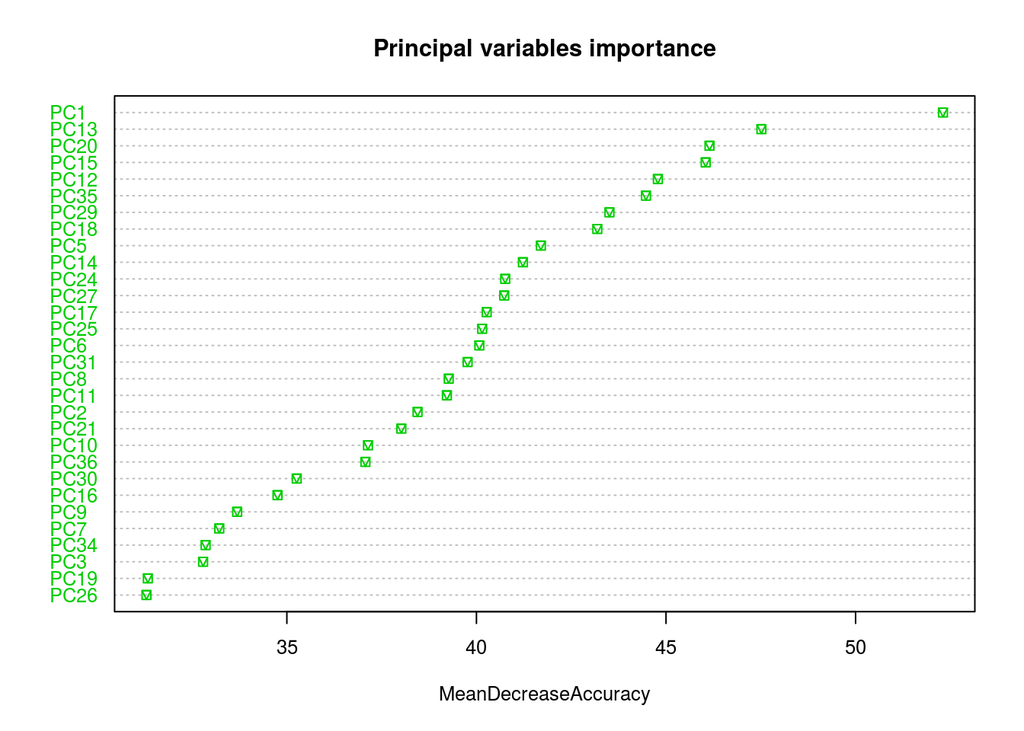

```r
varImpPlot(approach2$finalModel, sort = TRUE, type = 1, pch = 14, col = 3, cex = .8, main = "Principal variables importance")
```

Here, the degree of importance was shown on the x-axis increasing from left to right, whereas the principal variables were represented in the y-axis.

## Cross validation testing and out-of-sample error estimation

Now the predict funcion was used on the trained model to be applied to the cross validation test dataset.

```r
predictionTrain <- predict(approach2, validationTestPC)
confusionMatrix(trainValidation$classe, predictionTrain)
```

```
## Confusion Matrix and Statistics
##
##           Reference
## Prediction    A    B    C    D    E
##          A 1670    4    0    0    0
##          B   22 1110    5    1    1
##          C    0   12 1009    5    0
##          D    0    0   41  921    2
##          E    2    2   10   10 1058
##
## Overall Statistics
##
##                Accuracy : 0.98
##                  95% CI : (0.976, 0.984)
##     No Information Rate : 0.288
##     P-Value [Acc > NIR] : <2e-16
##
##                   Kappa : 0.975
##  Mcnemar's Test P-Value : NA
##
## Statistics by Class:
##
##                      Class: A Class: B Class: C Class: D Class: E
## Sensitivity             0.986    0.984    0.947    0.983    0.997
## Specificity             0.999    0.994    0.996    0.991    0.995
## Pos Pred Value          0.998    0.975    0.983    0.955    0.978
## Neg Pred Value          0.994    0.996    0.988    0.997    0.999
## Prevalence              0.288    0.192    0.181    0.159    0.180
## Detection Rate          0.284    0.189    0.171    0.156    0.180
## Detection Prevalence    0.284    0.194    0.174    0.164    0.184
## Balanced Accuracy       0.992    0.989    0.972    0.987    0.996
```

## Predicted Results

```r
testPC<-predict(preProcTrain, OKtest[,-53])
finalPrediction<-predict(approach2, testPC)
finalPrediction
```

```
##  [1] B A A A A C D B A A B C B A E E A B B B
## Levels: A B C D E
```